# Preliminary Analysis of Focused Attention Data

# Summary

This document contains an analysis of the Focused Attention data using [Model 3](https://rndtools.uhgrd.com/Print/InitiativeDocument/1090/MVP%20FA_data%20analysis%20plan_10.04.19_gka.pdf) on the [original feature list](https://rndtools.uhgrd.com/Project/Initiative/502#) which was provided before the start of the current [BT010-FA](https://rndtools.uhgrd.com/Project/Initiative/502) initiative. The results show that, for four of eight features, VR leads to a different physiological response compared to 2D, but only one feature seems to be materially effected by game difficulty. Consequently, this analysis provides little guidance on how game parameters can be manipulated to keep a patient’s stress response in a prespecified range using the current feature set. Next steps for the initiative would be to explore new features that may be associated with stress response.

# Results

For each feature, we show Type III sum of squares, all pairwise differences for the three-way treatment interactions, the difference in difference of physiological response between treatments delivered in 2D versus VR, and a plot of raw and fitted patient data with a 95% bootstrapped confidence interval for the respective mean. We dropped mean heart rate readings below 50, heart rate variability above 250, and skin temperature readings below 25 degrees celsius from the analysis, and log transformed most features to meet the normality assumptions for an ANOVA. Only the pairwise contrasts adjust for multiple comparisons (using Tukeys method), and this adjustment is made on the feature level, i.e. there are no adjustments for the fact that we conduct the analysis on eight different physiological features. The effects for game difficulty and perceptibility are not significant for most features; consequently, the results of our analysis do not provide clear support for the hypothesis that game parameters can be manipulated to keep a patient’s stress response in a prespecified range.

In our final analysis for the initiative, we need to adequately deal with outliers and bad data; for example, a heart rate of less than 25 is likely an erroneous data point. We need to agree upon ranges for parameters which make scientific sense, i.e. heart rate between 50 and 200, skin temperature above 25 degrees celsius, etc. As we go to real-time feature creation in our biofeedback pilots, adequate plans for dealing with erroneous data are needed. We ask that these ranges are included in the list of parameters that the Research team is expected to provide as part of deliverable two in grant one of [BT010-FA](https://rndtools.uhgrd.com/Project/Initiative/502).

```
## ###################################################################
## The response/dependent variable is: log_ecg_heart_rate_mean
## ###################################################################
## #**************************************************#
## ANOVA Table
## #**************************************************#
## Type III Analysis of Variance Table with Satterthwaite's method
##                                   Sum Sq   Mean Sq NumDF  DenDF F value  Pr(>F)
## time                           0.0110431 0.0036810     3 127.01  1.2805 0.28397
## type                           0.0075185 0.0075185     1 127.08  2.6154 0.10831
## difficulty                     0.0092098 0.0092098     1 127.02  3.2037 0.07586 .
## perceptibility                 0.0000088 0.0000088     1 127.01  0.0031 0.95600
## type:difficulty                0.0049143 0.0049143     1 127.02  1.7095 0.19341
## type:perceptibility            0.0003911 0.0003911     1 127.01  0.1360 0.71286
## difficulty:perceptibility      0.0030238 0.0030238     1 127.02  1.0519 0.30703
## type:difficulty:perceptibility 0.0009781 0.0009781     1 127.01  0.3402 0.56072
## ---
## Signif. codes:  0 '***' 0.001 '**' 0.01 '*' 0.05 '.' 0.1 ' ' 1
## #**************************************************#
## All third order pairwise contrasts
## Symbol order is Type:Diff:Percp
## #**************************************************#
## # A tibble: 28 x 6
##    contrast         estimate     SE    df  t.ratio p.value
##    <fct>               <dbl>  <dbl> <dbl>    <dbl>   <dbl>
##  1 2D,H,H - 3D,H,H -0.0234   0.0173  127. -1.35      0.877
##  2 2D,H,H - 2D,L,H -0.0131   0.0171  127. -0.768     0.994
##  3 2D,H,H - 3D,L,H -0.0241   0.0171  127. -1.41      0.850
##  4 2D,H,H - 2D,H,L  0.0112   0.0170  127.  0.660     0.998
##  5 2D,H,H - 3D,H,L -0.0158   0.0174  127. -0.909     0.985
##  6 2D,H,H - 2D,L,L -0.0299   0.0170  127. -1.76      0.649
##  7 2D,H,H - 3D,L,L -0.0242   0.0176  127. -1.37      0.867
##  8 3D,H,H - 2D,L,H  0.0102   0.0176  127.  0.584     0.999
##  9 3D,H,H - 3D,L,H -0.000718 0.0173  127. -0.0415    1.000
## 10 3D,H,H - 2D,H,L  0.0346   0.0173  127.  2.00      0.487
## 11 3D,H,H - 3D,H,L  0.00756  0.0176  127.  0.430     1.000
## 12 3D,H,H - 2D,L,L -0.00651  0.0173  127. -0.377     1.000
## 13 3D,H,H - 3D,L,L -0.000841 0.0181  127. -0.0464    1.000
## 14 2D,L,H - 3D,L,H -0.0110   0.0172  127. -0.638     0.998
## 15 2D,L,H - 2D,H,L  0.0243   0.0171  127.  1.42      0.846
```

[output cut: 12 more lines]

```
## 28 2D,L,L - 3D,L,L  0.00567  0.0177  127.  0.320     1.000
## #**************************************************#
## Difference in difference (2D - 3D)
## HL means Difficulty is High and Percept is Low
## Lower and Upper are from bootstrapped 95% CIs
## #**************************************************#
## # A tibble: 6 x 5
##   diff_params      mean     sd   lower  upper
##   <chr>           <dbl>  <dbl>   <dbl>  <dbl>
## 1 HH-HL        0.000540 0.0277 -0.0462 0.0554
## 2 HH-LH       -0.0205   0.0277 -0.0729 0.0311
## 3 HH-LL       -0.0236   0.0263 -0.0751 0.0265
## 4 HL-LH       -0.0210   0.0269 -0.0666 0.0301
## 5 HL-LL       -0.0241   0.0214 -0.0672 0.0208
## 6 LH-LL       -0.00312  0.0263 -0.0461 0.0435
```

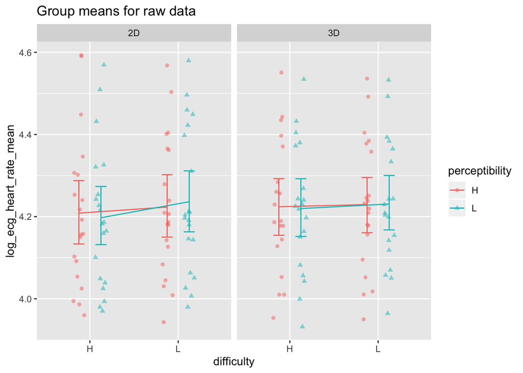

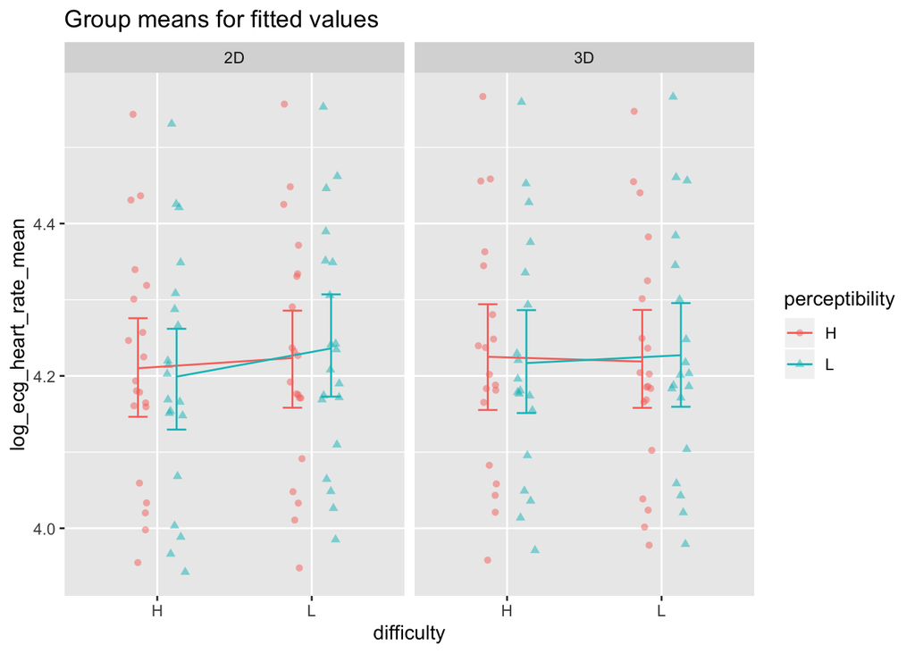

```
## ###################################################################
## The response/dependent variable is: log_ecg_hrv_std_mean
## ###################################################################
## #**************************************************#
## ANOVA Table
## #**************************************************#
## Type III Analysis of Variance Table with Satterthwaite's method
##                                 Sum Sq Mean Sq NumDF  DenDF F value  Pr(>F)
## time                           0.04060 0.01353     3 122.86  0.1113 0.95337
## type                           0.08493 0.08493     1 122.93  0.6983 0.40498
## difficulty                     0.79066 0.79066     1 122.98  6.5008 0.01201 *
## perceptibility                 0.19865 0.19865     1 122.83  1.6333 0.20365
## type:difficulty                0.47363 0.47363     1 123.03  3.8942 0.05069 .
## type:perceptibility            0.09421 0.09421     1 122.74  0.7746 0.38051
## difficulty:perceptibility      0.01505 0.01505     1 122.97  0.1237 0.72561
## type:difficulty:perceptibility 0.08614 0.08614     1 122.80  0.7082 0.40167
## ---
## Signif. codes:  0 '***' 0.001 '**' 0.01 '*' 0.05 '.' 0.1 ' ' 1
## #**************************************************#
## All third order pairwise contrasts
## Symbol order is Type:Diff:Percp
## #**************************************************#
## # A tibble: 28 x 6
##    contrast        estimate    SE    df t.ratio p.value
##    <fct>              <dbl> <dbl> <dbl>   <dbl>   <dbl>
##  1 2D,H,H - 3D,H,H  0.0681  0.115  122.  0.590   0.999
##  2 2D,H,H - 2D,L,H -0.0652  0.114  122. -0.573   0.999
##  3 2D,H,H - 3D,L,H -0.126   0.113  124. -1.11    0.953
##  4 2D,H,H - 2D,H,L -0.0500  0.113  122. -0.441   1.000
##  5 2D,H,H - 3D,H,L  0.0127  0.114  122.  0.112   1.000
##  6 2D,H,H - 2D,L,L -0.0588  0.113  122. -0.518   1.000
##  7 2D,H,H - 3D,L,L -0.319   0.116  122. -2.74    0.120
##  8 3D,H,H - 2D,L,H -0.133   0.117  122. -1.14    0.947
##  9 3D,H,H - 3D,L,H -0.194   0.115  124. -1.69    0.695
## 10 3D,H,H - 2D,H,L -0.118   0.116  122. -1.02    0.970
## 11 3D,H,H - 3D,H,L -0.0554  0.116  122. -0.477   1.000
## 12 3D,H,H - 2D,L,L -0.127   0.115  122. -1.10    0.956
## 13 3D,H,H - 3D,L,L -0.387   0.120  122. -3.22    0.0344
## 14 2D,L,H - 3D,L,H -0.0607  0.114  123. -0.534   0.999
## 15 2D,L,H - 2D,H,L  0.0152  0.114  122.  0.133   1.000
```

[output cut: 12 more lines]

```
## 28 2D,L,L - 3D,L,L -0.260   0.116  122. -2.23    0.341
## #**************************************************#
## Difference in difference (2D - 3D)
## HL means Difficulty is High and Percept is Low
## Lower and Upper are from bootstrapped 95% CIs
## #**************************************************#
## # A tibble: 6 x 5
##   diff_params     mean    sd    lower upper
##   <chr>          <dbl> <dbl>    <dbl> <dbl>
## 1 HH-HL       -0.00781 0.175 -0.341   0.292
## 2 HH-LH        0.136   0.178 -0.207   0.446
## 3 HH-LL        0.298   0.174 -0.0519  0.594
## 4 HL-LH        0.144   0.179 -0.189   0.512
## 5 HL-LL        0.305   0.157 -0.00652 0.684
## 6 LH-LL        0.162   0.183 -0.159   0.485
```

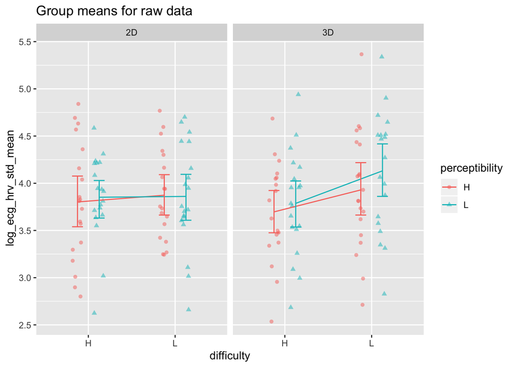

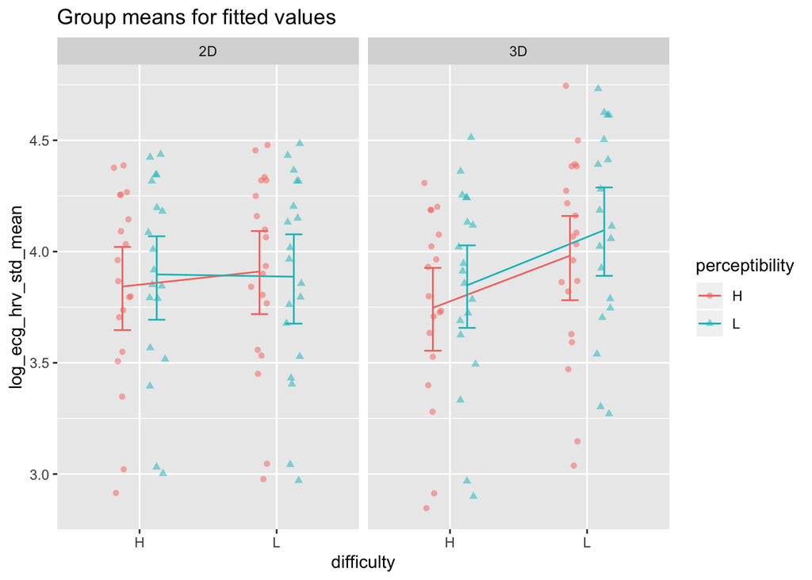

```
## ###################################################################
## The response/dependent variable is: skin_temperature_mean
## ###################################################################
## #**************************************************#
## ANOVA Table
## #**************************************************#
## Type III Analysis of Variance Table with Satterthwaite's method
##                                 Sum Sq Mean Sq NumDF  DenDF F value Pr(>F)
## time                           2.16294 0.72098     3 107.87  0.9361 0.4259
## type                           0.47821 0.47821     1 108.17  0.6209 0.4324
## difficulty                     0.12330 0.12330     1 107.87  0.1601 0.6899
## perceptibility                 0.00288 0.00288     1 107.87  0.0037 0.9513
## type:difficulty                0.00013 0.00013     1 107.87  0.0002 0.9897
## type:perceptibility            0.24306 0.24306     1 107.87  0.3156 0.5754
## difficulty:perceptibility      0.04804 0.04804     1 107.87  0.0624 0.8032
## type:difficulty:perceptibility 0.07605 0.07605     1 107.87  0.0987 0.7539
## #**************************************************#
## All third order pairwise contrasts
## Symbol order is Type:Diff:Percp
## #**************************************************#
## # A tibble: 28 x 6
##    contrast        estimate    SE    df t.ratio p.value
##    <fct>              <dbl> <dbl> <dbl>   <dbl>   <dbl>
##  1 2D,H,H - 3D,H,H -0.0841  0.305  108. -0.276    1.000
##  2 2D,H,H - 2D,L,H -0.0744  0.314  108. -0.237    1.000
##  3 2D,H,H - 3D,L,H -0.0581  0.310  108. -0.188    1.000
##  4 2D,H,H - 2D,H,L  0.0689  0.312  108.  0.221    1.000
##  5 2D,H,H - 3D,H,L -0.0952  0.308  108. -0.309    1.000
##  6 2D,H,H - 2D,L,L  0.0147  0.316  108.  0.0464   1.000
##  7 2D,H,H - 3D,L,L -0.242   0.307  108. -0.788    0.993
##  8 3D,H,H - 2D,L,H  0.00969 0.308  108.  0.0314   1.000
##  9 3D,H,H - 3D,L,H  0.0260  0.295  108.  0.0882   1.000
## 10 3D,H,H - 2D,H,L  0.153   0.305  108.  0.502    1.000
## 11 3D,H,H - 3D,H,L -0.0111  0.297  108. -0.0374   1.000
## 12 3D,H,H - 2D,L,L  0.0988  0.305  108.  0.323    1.000
## 13 3D,H,H - 3D,L,L -0.158   0.300  108. -0.527    0.999
## 14 2D,L,H - 3D,L,H  0.0163  0.310  108.  0.0526   1.000
## 15 2D,L,H - 2D,H,L  0.143   0.316  108.  0.453    1.000
## 16 2D,L,H - 3D,H,L -0.0208  0.311  108. -0.0670   1.000
## 17 2D,L,H - 2D,L,L  0.0891  0.316  108.  0.282    1.000
```

[output cut: 10 more lines]

```
## 28 2D,L,L - 3D,L,L -0.257   0.315  108. -0.815    0.992
## #**************************************************#
## Difference in difference (2D - 3D)
## HL means Difficulty is High and Percept is Low
## Lower and Upper are from bootstrapped 95% CIs
## #**************************************************#
## # A tibble: 6 x 5
##   diff_params    mean    sd  lower upper
##   <chr>         <dbl> <dbl>  <dbl> <dbl>
## 1 HH-HL        0.0583 0.458 -0.887 0.830
## 2 HH-LH       -0.0272 0.471 -0.813 0.771
## 3 HH-LL       -0.0425 0.442 -0.930 0.852
## 4 HL-LH       -0.0855 0.439 -1.01  0.675
## 5 HL-LL       -0.101  0.466 -1.03  0.781
## 6 LH-LL       -0.0154 0.456 -0.948 0.750
```

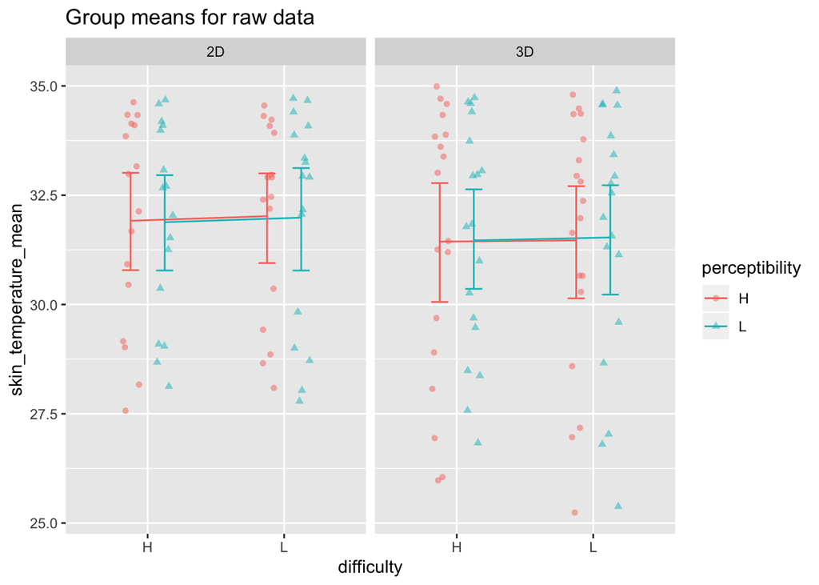

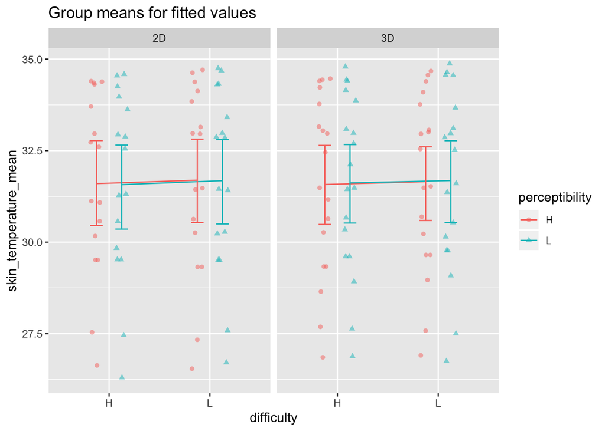

```
## ###################################################################
## The response/dependent variable is: eda_mean_mean
## ###################################################################
## #**************************************************#
## ANOVA Table
## #**************************************************#
## Type III Analysis of Variance Table with Satterthwaite's method
##                                Sum Sq Mean Sq NumDF DenDF F value    Pr(>F)
## time                            8.011   2.670     3   130  0.7204    0.5415
## type                           93.682  93.682     1   130 25.2724 1.614e-06 ***
## difficulty                      0.916   0.916     1   130  0.2470    0.6200
## perceptibility                  0.005   0.005     1   130  0.0012    0.9722
## type:difficulty                 0.024   0.024     1   130  0.0065    0.9358
## type:perceptibility             0.875   0.875     1   130  0.2359    0.6280
## difficulty:perceptibility       0.590   0.590     1   130  0.1592    0.6905
## type:difficulty:perceptibility  0.557   0.557     1   130  0.1502    0.6990
## ---
## Signif. codes:  0 '***' 0.001 '**' 0.01 '*' 0.05 '.' 0.1 ' ' 1
## #**************************************************#
## All third order pairwise contrasts
## Symbol order is Type:Diff:Percp
## #**************************************************#
## # A tibble: 28 x 6
##    contrast        estimate    SE    df t.ratio p.value
##    <fct>              <dbl> <dbl> <dbl>   <dbl>   <dbl>
##  1 2D,H,H - 3D,H,H  -1.54   0.610  130. -2.52    0.196
##  2 2D,H,H - 2D,L,H   0.177  0.613  130.  0.288   1.000
##  3 2D,H,H - 3D,L,H  -1.65   0.613  130. -2.69    0.134
##  4 2D,H,H - 2D,H,L  -0.144  0.610  130. -0.236   1.000
##  5 2D,H,H - 3D,H,L  -1.62   0.613  130. -2.64    0.152
##  6 2D,H,H - 2D,L,L   0.0388 0.610  130.  0.0636  1.000
##  7 2D,H,H - 3D,L,L  -1.25   0.620  130. -2.01    0.481
##  8 3D,H,H - 2D,L,H   1.71   0.618  130.  2.78    0.110
##  9 3D,H,H - 3D,L,H  -0.112  0.611  130. -0.183   1.000
## 10 3D,H,H - 2D,H,L   1.39   0.611  130.  2.28    0.312
## 11 3D,H,H - 3D,H,L  -0.0801 0.614  130. -0.131   1.000
## 12 3D,H,H - 2D,L,L   1.58   0.609  130.  2.59    0.170
## 13 3D,H,H - 3D,L,L   0.293  0.628  130.  0.466   1.000
## 14 2D,L,H - 3D,L,H  -1.83   0.617  130. -2.96    0.0691
## 15 2D,L,H - 2D,H,L  -0.321  0.615  130. -0.521   1.000
```

[output cut: 12 more lines]

```
## 28 2D,L,L - 3D,L,L  -1.28   0.624  130. -2.06    0.449
## #**************************************************#
## Difference in difference (2D - 3D)
## HL means Difficulty is High and Percept is Low
## Lower and Upper are from bootstrapped 95% CIs
## #**************************************************#
## # A tibble: 6 x 5
##   diff_params    mean    sd lower upper
##   <chr>         <dbl> <dbl> <dbl> <dbl>
## 1 HH-HL       -0.0734 0.856 -1.71  1.56
## 2 HH-LH        0.211  0.948 -1.48  1.89
## 3 HH-LL       -0.180  0.864 -1.89  1.48
## 4 HL-LH        0.284  0.965 -1.27  2.00
## 5 HL-LL       -0.106  0.751 -1.58  1.40
## 6 LH-LL       -0.390  0.934 -1.94  1.28
```

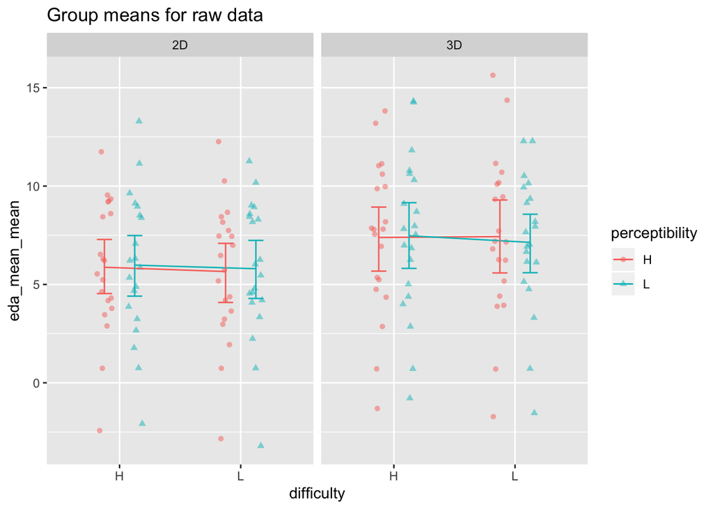

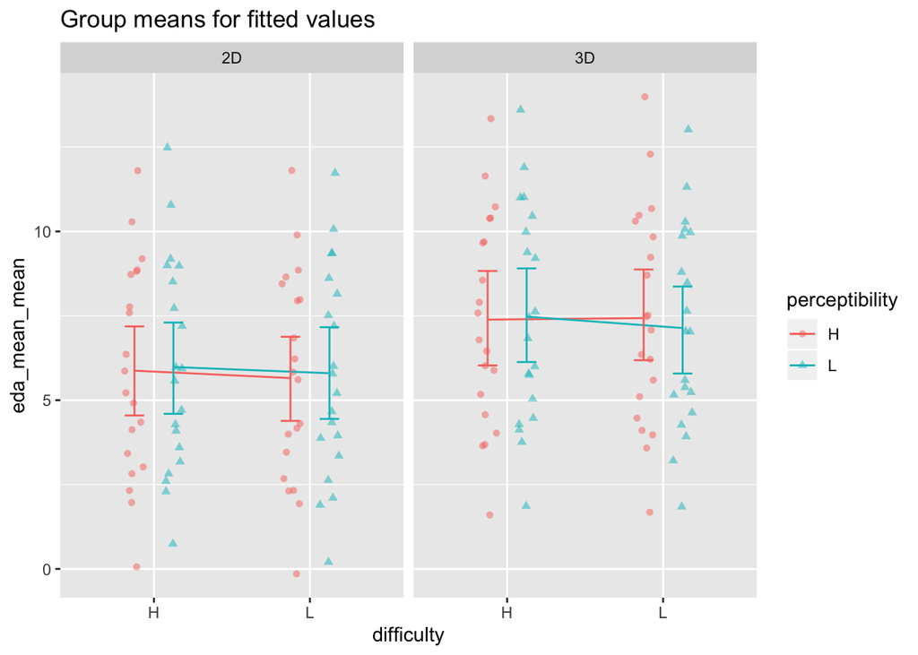

```
## ###################################################################
## The response/dependent variable is: log_eda_no_of_peaks_mean
## ###################################################################
## #**************************************************#
## ANOVA Table
## #**************************************************#
## Type III Analysis of Variance Table with Satterthwaite's method
##                                 Sum Sq Mean Sq NumDF DenDF F value  Pr(>F)
## time                           0.77053 0.25684     3   130  2.1012 0.10322
## type                           0.46564 0.46564     1   130  3.8093 0.05312 .
## difficulty                     0.02770 0.02770     1   130  0.2266 0.63484
## perceptibility                 0.00084 0.00084     1   130  0.0069 0.93399
## type:difficulty                0.03534 0.03534     1   130  0.2891 0.59171
## type:perceptibility            0.09150 0.09150     1   130  0.7485 0.38854
## difficulty:perceptibility      0.04947 0.04947     1   130  0.4047 0.52579
## type:difficulty:perceptibility 0.58089 0.58089     1   130  4.7521 0.03106 *
## ---
## Signif. codes:  0 '***' 0.001 '**' 0.01 '*' 0.05 '.' 0.1 ' ' 1
## #**************************************************#
## All third order pairwise contrasts
## Symbol order is Type:Diff:Percp
## #**************************************************#
## # A tibble: 28 x 6
##    contrast        estimate    SE    df t.ratio p.value
##    <fct>              <dbl> <dbl> <dbl>   <dbl>   <dbl>
##  1 2D,H,H - 3D,H,H  0.249   0.111  130.  2.25     0.330
##  2 2D,H,H - 2D,L,H  0.101   0.111  130.  0.906    0.985
##  3 2D,H,H - 3D,L,H  0.165   0.111  130.  1.49     0.813
##  4 2D,H,H - 2D,H,L  0.202   0.111  130.  1.82     0.605
##  5 2D,H,H - 3D,H,L  0.109   0.111  130.  0.979    0.977
##  6 2D,H,H - 2D,L,L -0.0124  0.111  130. -0.112    1.000
##  7 2D,H,H - 3D,L,L  0.198   0.113  130.  1.76     0.646
##  8 3D,H,H - 2D,L,H -0.148   0.112  130. -1.32     0.889
##  9 3D,H,H - 3D,L,H -0.0838  0.111  130. -0.755    0.995
## 10 3D,H,H - 2D,H,L -0.0471  0.111  130. -0.425    1.000
## 11 3D,H,H - 3D,H,L -0.140   0.111  130. -1.26     0.912
## 12 3D,H,H - 2D,L,L -0.262   0.111  130. -2.36     0.268
## 13 3D,H,H - 3D,L,L -0.0508  0.114  130. -0.446    1.000
## 14 2D,L,H - 3D,L,H  0.0646  0.112  130.  0.577    0.999
## 15 2D,L,H - 2D,H,L  0.101   0.112  130.  0.906    0.985
```

[output cut: 12 more lines]

```
## 28 2D,L,L - 3D,L,L  0.211   0.113  130.  1.86     0.581
## #**************************************************#
## Difference in difference (2D - 3D)
## HL means Difficulty is High and Percept is Low
## Lower and Upper are from bootstrapped 95% CIs
## #**************************************************#
## # A tibble: 6 x 5
##   diff_params    mean    sd   lower   upper
##   <chr>         <dbl> <dbl>   <dbl>   <dbl>
## 1 HH-HL        0.323  0.155  0.0264  0.619
## 2 HH-LH        0.180  0.172 -0.126   0.484
## 3 HH-LL        0.0165 0.157 -0.295   0.318
## 4 HL-LH       -0.143  0.175 -0.426   0.169
## 5 HL-LL       -0.306  0.136 -0.573  -0.0333
## 6 LH-LL       -0.163  0.170 -0.444   0.141
```

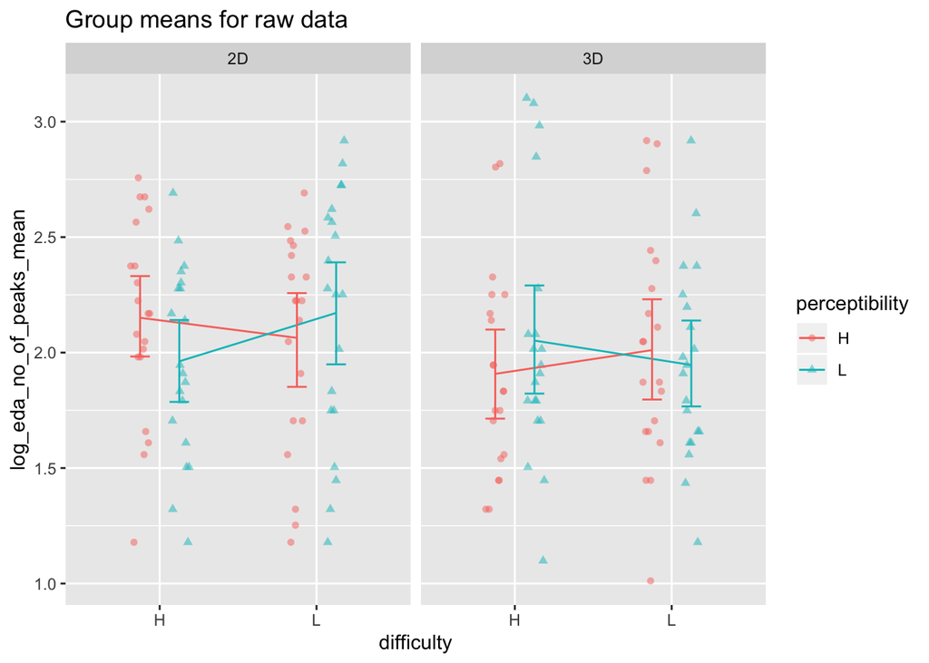

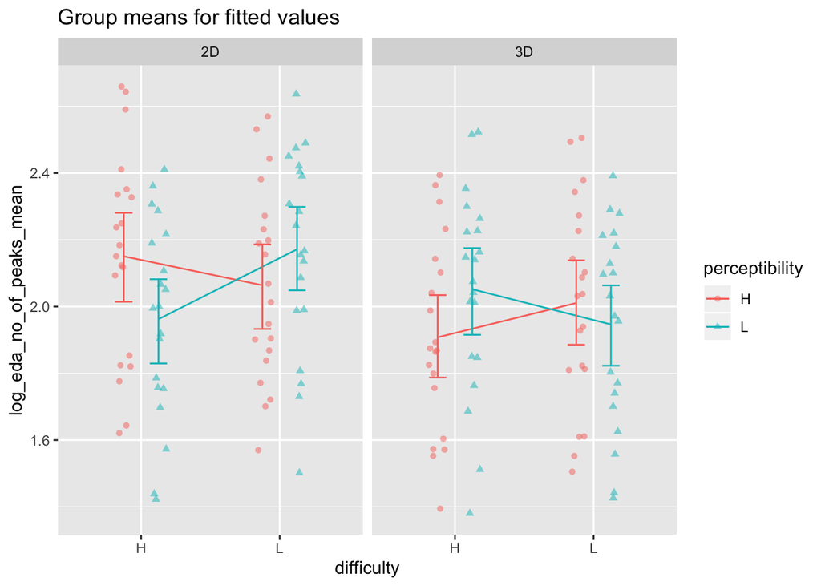

```
## ###################################################################
## The response/dependent variable is: log_eda_lf_mean
## ###################################################################
## #**************************************************#
## ANOVA Table
## #**************************************************#
## Type III Analysis of Variance Table with Satterthwaite's method
##                                 Sum Sq Mean Sq NumDF DenDF F value  Pr(>F)
## time                            4.0586  1.3529     3   130  1.0424 0.37615
## type                           12.4972 12.4972     1   130  9.6295 0.00235 **
## difficulty                      1.2478  1.2478     1   130  0.9615 0.32863
## perceptibility                  0.1312  0.1312     1   130  0.1011 0.75107
## type:difficulty                 2.6208  2.6208     1   130  2.0194 0.15769
## type:perceptibility             1.9602  1.9602     1   130  1.5104 0.22130
## difficulty:perceptibility       0.2321  0.2321     1   130  0.1789 0.67306
## type:difficulty:perceptibility  0.7016  0.7016     1   130  0.5406 0.46352
## ---
## Signif. codes:  0 '***' 0.001 '**' 0.01 '*' 0.05 '.' 0.1 ' ' 1
## #**************************************************#
## All third order pairwise contrasts
## Symbol order is Type:Diff:Percp
## #**************************************************#
## # A tibble: 28 x 6
##    contrast        estimate    SE    df t.ratio p.value
##    <fct>              <dbl> <dbl> <dbl>   <dbl>   <dbl>
##  1 2D,H,H - 3D,H,H  -1.18   0.361  130. -3.26    0.0299
##  2 2D,H,H - 2D,L,H  -0.133  0.363  130. -0.367   1.000
##  3 2D,H,H - 3D,L,H  -0.528  0.363  130. -1.46    0.829
##  4 2D,H,H - 2D,H,L  -0.342  0.361  130. -0.946   0.981
##  5 2D,H,H - 3D,H,L  -0.796  0.363  130. -2.19    0.362
##  6 2D,H,H - 2D,L,L  -0.360  0.361  130. -0.998   0.974
##  7 2D,H,H - 3D,L,L  -0.570  0.367  130. -1.55    0.777
##  8 3D,H,H - 2D,L,H   1.04   0.365  130.  2.86    0.0903
##  9 3D,H,H - 3D,L,H   0.649  0.361  130.  1.80    0.624
## 10 3D,H,H - 2D,H,L   0.835  0.361  130.  2.31    0.296
## 11 3D,H,H - 3D,H,L   0.381  0.363  130.  1.05    0.966
## 12 3D,H,H - 2D,L,L   0.817  0.360  130.  2.27    0.321
## 13 3D,H,H - 3D,L,L   0.607  0.371  130.  1.64    0.728
## 14 2D,L,H - 3D,L,H  -0.395  0.365  130. -1.08    0.960
## 15 2D,L,H - 2D,H,L  -0.209  0.364  130. -0.573   0.999
```

[output cut: 12 more lines]

```
## 28 2D,L,L - 3D,L,L  -0.209  0.369  130. -0.567   0.999
## #**************************************************#
## Difference in difference (2D - 3D)
## HL means Difficulty is High and Percept is Low
## Lower and Upper are from bootstrapped 95% CIs
## #**************************************************#
## # A tibble: 6 x 5
##   diff_params    mean    sd  lower upper
##   <chr>         <dbl> <dbl>  <dbl> <dbl>
## 1 HH-HL       -0.728  0.507 -1.69  0.236
## 2 HH-LH       -0.854  0.561 -1.85  0.138
## 3 HH-LL       -0.836  0.511 -1.85  0.146
## 4 HL-LH       -0.126  0.571 -1.05  0.890
## 5 HL-LL       -0.108  0.445 -0.978 0.781
## 6 LH-LL        0.0174 0.553 -0.897 1.01
```

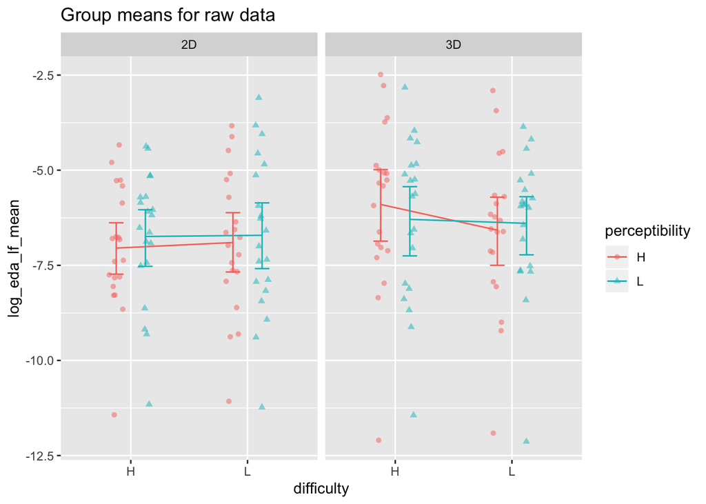

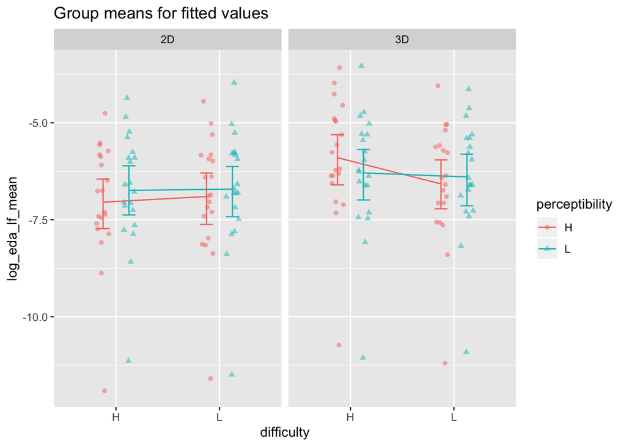

```
## ###################################################################
## The response/dependent variable is: log_eda_hf_mean
## ###################################################################
## #**************************************************#
## ANOVA Table
## #**************************************************#
## Type III Analysis of Variance Table with Satterthwaite's method
##                                 Sum Sq Mean Sq NumDF DenDF F value   Pr(>F)
## time                            4.4273  1.4758     3   130  1.1992 0.312780
## type                           10.3050 10.3050     1   130  8.3736 0.004466 **
## difficulty                      1.2307  1.2307     1   130  1.0000 0.319168
## perceptibility                  0.0897  0.0897     1   130  0.0729 0.787649
## type:difficulty                 2.5738  2.5738     1   130  2.0914 0.150533
## type:perceptibility             2.2290  2.2290     1   130  1.8112 0.180706
## difficulty:perceptibility       0.1325  0.1325     1   130  0.1076 0.743380
## type:difficulty:perceptibility  0.5891  0.5891     1   130  0.4787 0.490249
## ---
## Signif. codes:  0 '***' 0.001 '**' 0.01 '*' 0.05 '.' 0.1 ' ' 1
## #**************************************************#
## All third order pairwise contrasts
## Symbol order is Type:Diff:Percp
## #**************************************************#
## # A tibble: 28 x 6
##    contrast        estimate    SE    df t.ratio p.value
##    <fct>              <dbl> <dbl> <dbl>   <dbl>   <dbl>
##  1 2D,H,H - 3D,H,H -1.13    0.352  130. -3.21    0.0351
##  2 2D,H,H - 2D,L,H -0.140   0.353  130. -0.395   1.000
##  3 2D,H,H - 3D,L,H -0.512   0.353  130. -1.45    0.832
##  4 2D,H,H - 2D,H,L -0.354   0.352  130. -1.01    0.973
##  5 2D,H,H - 3D,H,L -0.752   0.353  130. -2.13    0.403
##  6 2D,H,H - 2D,L,L -0.364   0.351  130. -1.04    0.968
##  7 2D,H,H - 3D,L,L -0.498   0.357  130. -1.39    0.858
##  8 3D,H,H - 2D,L,H  0.987   0.356  130.  2.78    0.110
##  9 3D,H,H - 3D,L,H  0.616   0.352  130.  1.75    0.655
## 10 3D,H,H - 2D,H,L  0.773   0.352  130.  2.20    0.361
## 11 3D,H,H - 3D,H,L  0.376   0.354  130.  1.06    0.963
## 12 3D,H,H - 2D,L,L  0.763   0.351  130.  2.17    0.375
## 13 3D,H,H - 3D,L,L  0.629   0.362  130.  1.74    0.662
## 14 2D,L,H - 3D,L,H -0.372   0.355  130. -1.05    0.966
## 15 2D,L,H - 2D,H,L -0.215   0.354  130. -0.606   0.999
```

[output cut: 12 more lines]

```
## 28 2D,L,L - 3D,L,L -0.134   0.360  130. -0.373   1.000
## #**************************************************#
## Difference in difference (2D - 3D)
## HL means Difficulty is High and Percept is Low
## Lower and Upper are from bootstrapped 95% CIs
## #**************************************************#
## # A tibble: 6 x 5
##   diff_params    mean    sd  lower upper
##   <chr>         <dbl> <dbl>  <dbl> <dbl>
## 1 HH-HL       -0.728  0.493 -1.67  0.210
## 2 HH-LH       -0.830  0.546 -1.80  0.136
## 3 HH-LL       -0.853  0.498 -1.84  0.104
## 4 HL-LH       -0.102  0.556 -0.999 0.887
## 5 HL-LL       -0.125  0.433 -0.971 0.742
## 6 LH-LL       -0.0229 0.538 -0.913 0.941
```

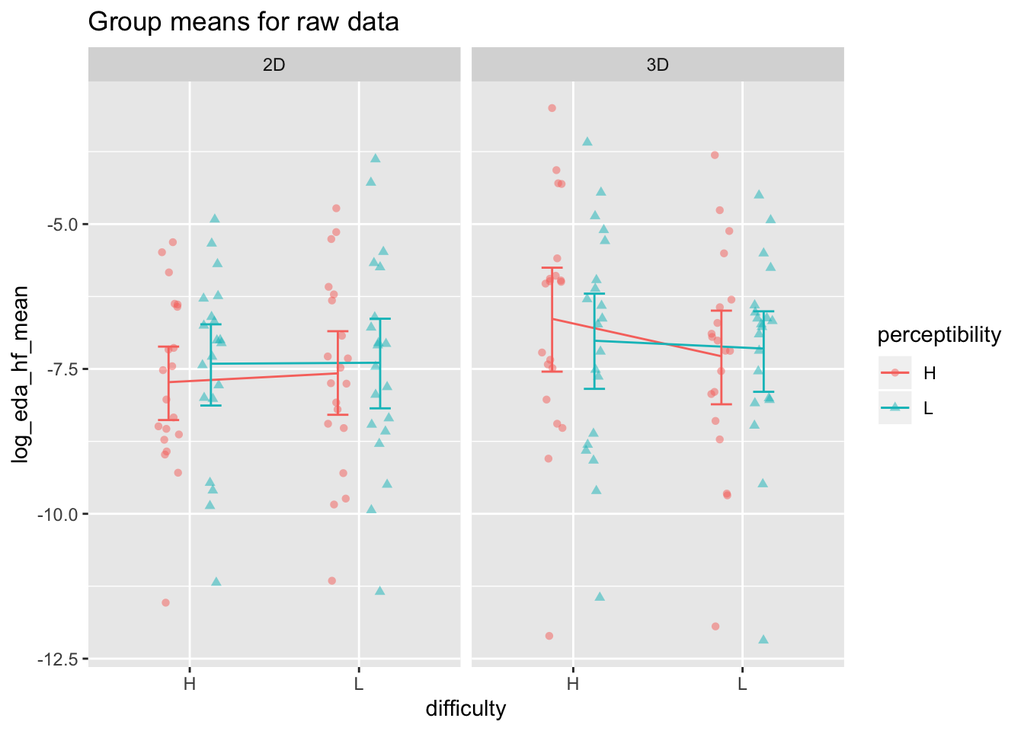

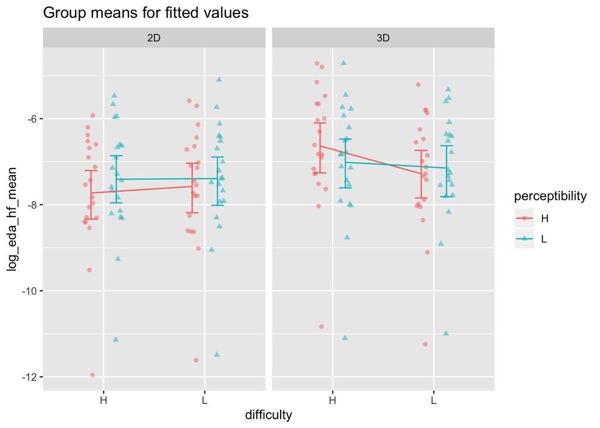

```
## ###################################################################
## The response/dependent variable is: log_eda_lf_hf_ratio_mean
## ###################################################################
## #**************************************************#
## ANOVA Table
## #**************************************************#
## Type III Analysis of Variance Table with Satterthwaite's method
##                                  Sum Sq  Mean Sq NumDF DenDF F value Pr(>F)
## time                           0.018792 0.006264     3   130  0.1387 0.9367
## type                           0.070668 0.070668     1   130  1.5645 0.2133
## difficulty                     0.003217 0.003217     1   130  0.0712 0.7900
## perceptibility                 0.009851 0.009851     1   130  0.2181 0.6413
## type:difficulty                0.031224 0.031224     1   130  0.6913 0.4073
## type:perceptibility            0.011776 0.011776     1   130  0.2607 0.6105
## difficulty:perceptibility      0.027370 0.027370     1   130  0.6059 0.4377
## type:difficulty:perceptibility 0.019864 0.019864     1   130  0.4398 0.5084
## #**************************************************#
## All third order pairwise contrasts
## Symbol order is Type:Diff:Percp
## #**************************************************#
## # A tibble: 28 x 6
##    contrast        estimate     SE    df t.ratio p.value
##    <fct>              <dbl>  <dbl> <dbl>   <dbl>   <dbl>
##  1 2D,H,H - 3D,H,H -0.0190  0.0673  130. -0.282    1.000
##  2 2D,H,H - 2D,L,H  0.0227  0.0677  130.  0.335    1.000
##  3 2D,H,H - 3D,L,H -0.00721 0.0676  130. -0.107    1.000
##  4 2D,H,H - 2D,H,L  0.00566 0.0674  130.  0.0840   1.000
##  5 2D,H,H - 3D,H,L -0.00333 0.0677  130. -0.0492   1.000
##  6 2D,H,H - 2D,L,L  0.0207  0.0673  130.  0.307    1.000
##  7 2D,H,H - 3D,L,L -0.0896  0.0685  130. -1.31     0.894
##  8 3D,H,H - 2D,L,H  0.0417  0.0682  130.  0.611    0.999
##  9 3D,H,H - 3D,L,H  0.0118  0.0674  130.  0.175    1.000
## 10 3D,H,H - 2D,H,L  0.0247  0.0674  130.  0.366    1.000
## 11 3D,H,H - 3D,H,L  0.0157  0.0678  130.  0.231    1.000
## 12 3D,H,H - 2D,L,L  0.0397  0.0673  130.  0.590    0.999
## 13 3D,H,H - 3D,L,L -0.0706  0.0693  130. -1.02     0.971
## 14 2D,L,H - 3D,L,H -0.0299  0.0681  130. -0.439    1.000
## 15 2D,L,H - 2D,H,L -0.0170  0.0679  130. -0.251    1.000
## 16 2D,L,H - 3D,H,L -0.0260  0.0684  130. -0.380    1.000
## 17 2D,L,H - 2D,L,L -0.00202 0.0679  130. -0.0297   1.000
```

[output cut: 10 more lines]

```
## 28 2D,L,L - 3D,L,L -0.110   0.0689  130. -1.60     0.750
## #**************************************************#
## Difference in difference (2D - 3D)
## HL means Difficulty is High and Percept is Low
## Lower and Upper are from bootstrapped 95% CIs
## #**************************************************#
## # A tibble: 6 x 5
##   diff_params     mean     sd   lower upper
##   <chr>          <dbl>  <dbl>   <dbl> <dbl>
## 1 HH-HL       -0.0152  0.0945 -0.195  0.165
## 2 HH-LH        0.00281 0.105  -0.183  0.188
## 3 HH-LL        0.0986  0.0954 -0.0906 0.282
## 4 HL-LH        0.0180  0.107  -0.154  0.207
## 5 HL-LL        0.114   0.0830 -0.0485 0.280
## 6 LH-LL        0.0958  0.103  -0.0748 0.281
```

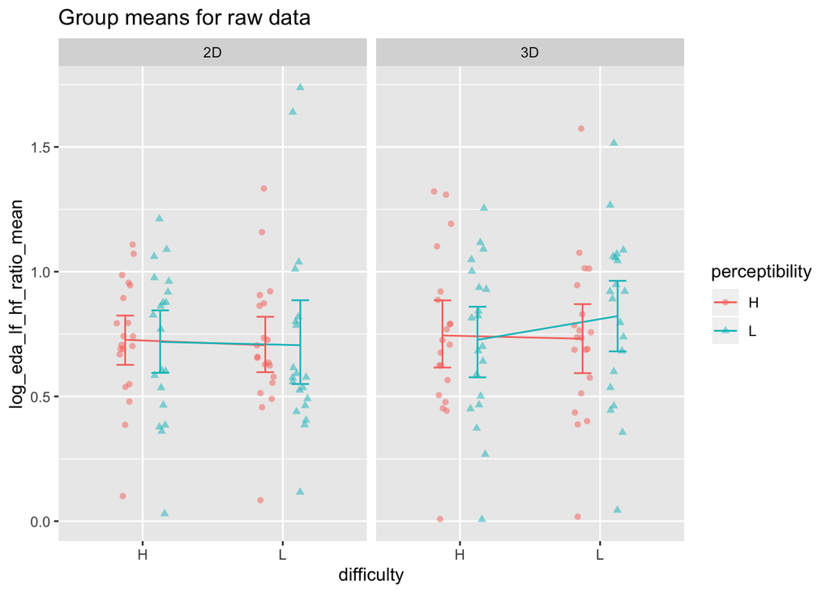

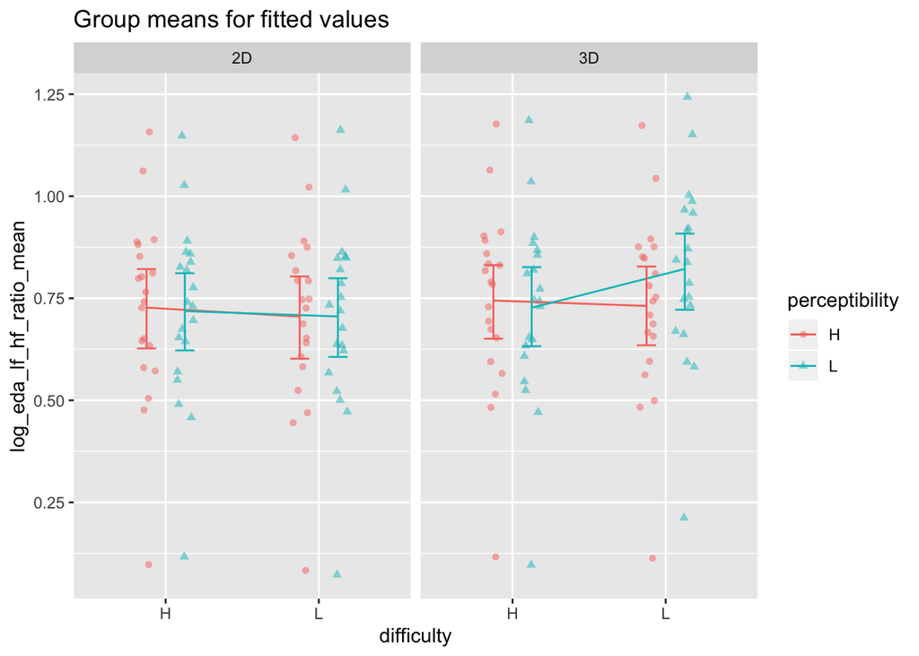